# Dynamic Discrete Choice

## 1. Motivation

- Dynamic discrete choices are forward-looking because today’s action changes tomorrow’s state.
- In a minimal version of Rust’s replacement problem, an owner chooses whether to keep a costly machine or replace it and reset its condition.
- With one state, two choices, and two cost parameters, the model introduces value functions, conditional choice probabilities, and NFXP estimation.

## 2. Dynamic Discrete Choice Theory

### 2.1 Model Setup

- Single agent and infinite-horizon discrete time: $t=0,1,2,\ldots$.
- The observed state is the machine condition:

$$x_t \in \mathcal{X}=\{0,1,\ldots,K\},$$

- A larger state means a machine in worse condition.
- The owner chooses:

$$d_t \in \mathcal{D}=\{0,1\},$$

- $d_t=0$ means **keep**; and
- $d_t=1$ means **replace**.
- Timing within each period:
  1. The owner observes $x_t$ and the choice shocks $\boldsymbol{\varepsilon}_t=(\varepsilon_{t0},\varepsilon_{t1})$.
  2. The owner chooses $d_t$.
  3. The owner receives current utility.
  4. The next state $x_{t+1}$ is drawn from the transition distribution associated with the chosen action.
- Period utility from action $d$ is:

$$u(x,d;\theta)+\varepsilon_d,
\qquad
\theta=(c,RC),$$

- Mean utilities are:

$$u(x,0;\theta)=-cx,
\qquad
u(x,1;\theta)=-RC.$$

- The parameter $c>0$ determines how quickly operating costs increase with the condition state.
- The parameter $RC>0$ is the replacement cost.
- If the owner keeps the machine, its condition stays unchanged or deteriorates by one step:

$$x_{t+1}
=
\min\{x_t+z_{t+1},K\},
\qquad
z_{t+1}\sim\operatorname{Bernoulli}(p).$$

- If the owner replaces the machine, the next state is $x_{t+1}=0$.
- Let $P_d(x' \mid x)$ denote the transition probability under action $d$.
- We treat the following objects as known:
  - the discount factor $\beta\in(0,1)$; and
  - the deterioration probability $p$.
- We estimate $c$ and $RC$.
- Choice shocks are:
  - independent across time, actions, and owners;
  - Type I extreme value; and
  - independent of the state transitions.

### 2.2 Choice-Specific Value Function

- The choice-specific value of choosing action $d$ today is:

$$v_d(x;\theta)
=
u(x,d;\theta)
+
\beta
\sum_{x'\in\mathcal{X}}
P_d(x'\mid x)V(x';\theta).$$

- For **keep**:

$$v_0(x;\theta)
=
-cx
+
\beta
\sum_{x'\in\mathcal{X}}
P_0(x'\mid x)V(x';\theta)$$

- For **replace**:

$$v_1(x;\theta)
=
-RC+\beta V(0;\theta).$$

- Each choice-specific value equals:
  - current mean utility; plus
  - the expected discounted continuation value.

### 2.3 Integrated Value Function

- Before the choice shocks are observed, the value of state $x$ is:

$$V(x;\theta)
=
\mathbb{E}_{\boldsymbol{\varepsilon}}
\left[
\max_{d\in\{0,1\}}
\left\{
v_d(x;\theta)+\varepsilon_d
\right\}
\right].$$

- Type I extreme value shocks give the log-sum-exp formula:

$$V(x;\theta)
=
\log
\left[
\exp\{v_0(x;\theta)\}
+
\exp\{v_1(x;\theta)\}
\right].$$

- We omit Euler’s constant:
  - it is choice-independent; and
  - removing it does not change choice probabilities.
- Because each $v_d$ contains the future value function, this equation is a fixed point.
- For a given parameter vector $\theta$, value-function iteration applies:

$$V^{(k+1)}(x)
=
\log
\left[
\exp\{v_0^{(k)}(x;\theta)\}
+
\exp\{v_1^{(k)}(x;\theta)\}
\right]$$

- Stop when $V^{(k+1)}$ and $V^{(k)}$ are sufficiently close.
- With $\beta\in(0,1)$, the Bellman operator is a contraction, so the fixed point is unique.

### 2.4 Conditional Choice Probabilities

- A conditional choice probability (CCP) is the probability of an action given the observed state.
- Type I extreme value shocks imply:

$$\Pr(d_t=d\mid x_t=x;\theta)
=
\frac{
\exp\{v_d(x;\theta)\}
}{
\exp\{v_0(x;\theta)\}
+
\exp\{v_1(x;\theta)\}
}.$$

- The replacement probability is:

$$\Pr(d_t=1\mid x_t=x;\theta)
=
\frac{
\exp\{v_1(x;\theta)\}
}{
\exp\{v_0(x;\theta)\}
+
\exp\{v_1(x;\theta)\}
}.$$

- This is the usual logit formula:
  - dynamics enter through the choice-specific values; and
  - replacement becomes more likely as its value rises relative to the keep value.

### 2.5 Estimation with the NFXP Algorithm

- The data contain $(x_i,d_i)$ for $i=1,\ldots,N$.
- Conditional on the observed states, the log-likelihood is:

$$\ell(\theta)
=
\sum_{i=1}^{N}
\log
\Pr(d_i\mid x_i;\theta).$$

- NFXP evaluates the likelihood through two loops:
  1. **Inner loop:** For a trial value of $\theta$, solve the integrated value function fixed point and compute the CCPs.
  2. **Outer loop:** Use the resulting CCPs to evaluate $\ell(\theta)$ and update $\theta$ with a numerical optimizer.
- Each likelihood evaluation follows:

$$\theta
\longrightarrow
V_{\theta}
\longrightarrow
\Pr_{\theta}(d\mid x)
\longrightarrow
\ell(\theta).$$

- NFXP is direct but can be costly because the fixed point is solved at every trial parameter vector.

## 3. Julia Coding Demo

- The code follows the same order as the theory:
  1. Construct the model.
  2. Solve its dynamic program.
  3. Simulate a synthetic panel.
  4. Inspect one-dimensional objective profiles.
  5. Estimate the two cost parameters by NFXP.

### 3.1 Packages and Model Constructor

- This cell only loads the packages used in the demo. It does not implement a model equation.

```julia
using Optim
using Plots
using Printf
using Random
using Statistics
```

- The next cell implements the state transitions from Section 2.1:

$$x_{t+1}
=
\begin{cases}
\min\{x_t+z_{t+1},K\}, & d_t=0,\\
0, & d_t=1,
\end{cases}
\qquad
z_{t+1}\sim\operatorname{Bernoulli}(p).$$

- **`transition_matrices`:** Builds $P_0$ and $P_1$.
  - Rows represent the current state.
  - Columns represent the next state.
- **`ReplacementModel`:** Stores the state-space size, $\beta$, $p$, and the two transition matrices.

```julia
struct ReplacementModel
    n_states::Int
    discount_factor::Float64
    deterioration_probability::Float64
    transition_keep::Matrix{Float64}
    transition_replace::Matrix{Float64}
end

function transition_matrices(; n_states, deterioration_probability)
    transition_keep = zeros(n_states, n_states)
    transition_replace = zeros(n_states, n_states)
    maximum_state = n_states - 1

    for state in 0:maximum_state
        row = state + 1
        next_state = min(state + 1, maximum_state)

        transition_keep[row, row] += 1 - deterioration_probability
        transition_keep[row, next_state + 1] +=
            deterioration_probability
        transition_replace[row, 1] = 1.0
    end

    return transition_keep, transition_replace
end

function ReplacementModel(;
    n_states = 8,
    discount_factor = 0.95,
    deterioration_probability = 0.65,
)
    transition_keep, transition_replace = transition_matrices(
        n_states = n_states,
        deterioration_probability = deterioration_probability,
    )

    return ReplacementModel(
        n_states,
        discount_factor,
        deterioration_probability,
        transition_keep,
        transition_replace,
    )
end

model = ReplacementModel()

@show sum(model.transition_keep; dims = 2)
@show sum(model.transition_replace; dims = 2)
nothing
```

```
sum(model.transition_keep; dims = 2) = [1.0; 1.0; 1.0; 1.0; 1.0; 1.0; 1.0; 1.0;;]
sum(model.transition_replace; dims = 2) = [1.0; 1.0; 1.0; 1.0; 1.0; 1.0; 1.0; 1.0;;]
```

- **Check:** Each row sums to one, as required for a transition probability.

### 3.2 Choice-Specific Values

- This cell implements the choice-specific values from Section 2.2:

$$\begin{aligned}
v_0(x;\theta)
&=
-cx
+
\beta
\sum_{x'\in\mathcal{X}}
P_0(x'\mid x)V(x';\theta),\\
v_1(x;\theta)
&=
-RC+\beta V(0;\theta).
\end{aligned}$$

- **Current utility:** `utility_keep` computes $-cx$, and `utility_replace` computes $-RC$.
- **Continuation value:** Each transition matrix multiplies the current guess of $V$.
- **Output:** The two columns contain $v_0(x;\theta)$ and $v_1(x;\theta)$.

```julia
function choice_specific_values(; model, parameters, value)
    operating_cost, replacement_cost = parameters
    states = collect(0:(model.n_states - 1))

    utility_keep = -operating_cost .* states
    utility_replace = fill(-replacement_cost, model.n_states)

    value_keep =
        utility_keep +
        model.discount_factor .* (model.transition_keep * value)
    value_replace =
        utility_replace +
        model.discount_factor .* (model.transition_replace * value)

    return hcat(value_keep, value_replace)
end
```

```
choice_specific_values (generic function with 1 method)
```

### 3.3 Integrated Value and CCPs

- This cell implements the integrated value from Section 2.3:

$$V(x;\theta)
=
\log
\left[
\exp\{v_0(x;\theta)\}
+
\exp\{v_1(x;\theta)\}
\right].$$

- It also implements the CCPs from Section 2.4:

$$\Pr(d_t=d\mid x_t=x;\theta)
=
\frac{
\exp\{v_d(x;\theta)\}
}{
\exp\{v_0(x;\theta)\}
+
\exp\{v_1(x;\theta)\}
}.$$

- **`integrated_value`:** Uses a stable log-sum-exp calculation.
- **`log_choice_probabilities`:** Computes $\log\Pr(d\mid x;\theta)=v_d(x;\theta)-V(x;\theta)$.
- **`choice_probabilities`:** Exponentiates the log CCPs.

```julia
function integrated_value(; choice_values)
    row_maximum = maximum(choice_values; dims = 2)
    return vec(
        row_maximum +
        log.(sum(exp.(choice_values .- row_maximum); dims = 2)),
    )
end

function log_choice_probabilities(; choice_values)
    value = integrated_value(choice_values = choice_values)
    return choice_values .- reshape(value, :, 1)
end

function choice_probabilities(; choice_values)
    return exp.(
        log_choice_probabilities(choice_values = choice_values),
    )
end
```

```
choice_probabilities (generic function with 1 method)
```

### 3.4 Value-Function Iteration

- This cell implements the fixed-point iteration from Section 2.3:

$$V^{(k+1)}(x)
=
\log
\left[
\exp\{v_0^{(k)}(x;\theta)\}
+
\exp\{v_1^{(k)}(x;\theta)\}
\right].$$

- The stopping rule is:

$$\left\lVert
V^{(k+1)}-V^{(k)}
\right\rVert_{\infty}
<
\text{tolerance}.$$

- **`solve_value_function`:** Alternates between choice-specific values and the integrated value until the stopping rule holds.
- **`solve_model`:** Uses the converged value function to return the choice-specific values and CCPs.

```julia
function solve_value_function(;
    model,
    parameters,
    tolerance = 1.0e-10,
    maximum_iterations = 10_000,
)
    value = zeros(model.n_states)

    for iteration in 1:maximum_iterations
        choice_values = choice_specific_values(
            model = model,
            parameters = parameters,
            value = value,
        )
        updated_value = integrated_value(
            choice_values = choice_values,
        )

        if maximum(abs.(updated_value .- value)) < tolerance
            return (
                value = updated_value,
                iterations = iteration,
            )
        end

        value = updated_value
    end

    error("Value-function iteration did not converge.")
end

function solve_model(; model, parameters)
    solution = solve_value_function(
        model = model,
        parameters = parameters,
    )
    choice_values = choice_specific_values(
        model = model,
        parameters = parameters,
        value = solution.value,
    )

    return (
        value = solution.value,
        choice_values = choice_values,
        choice_probabilities = choice_probabilities(
            choice_values = choice_values,
        ),
        iterations = solution.iterations,
    )
end
```

```
solve_model (generic function with 1 method)
```

### 3.5 Simulating a Synthetic Panel

- This cell generates data using the CCPs and state transitions:

$$d_t
\sim
\operatorname{Bernoulli}
\left(
\Pr(d_t=1\mid x_t;\theta)
\right),
\qquad
x_{t+1}
\sim
P_{d_t}(\cdot\mid x_t).$$

- First, solve the model at the true parameter values.
- For each machine and period:
  1. draw the action from the replacement probability; and
  2. draw the next state using the transition rule.
- Every simulated machine begins in state zero.

```julia
function simulate_panel(;
    model,
    parameters,
    n_units = 2_000,
    n_periods = 30,
    seed = 2026,
)
    rng = MersenneTwister(seed)
    solution = solve_model(
        model = model,
        parameters = parameters,
    )
    probabilities = solution.choice_probabilities
    n_observations = n_units * n_periods
    states = Vector{Int}(undef, n_observations)
    actions = Vector{Int}(undef, n_observations)

    observation = 0
    for unit in 1:n_units
        state = 0

        for period in 1:n_periods
            observation += 1
            replacement_probability = probabilities[state + 1, 2]
            action = rand(rng) < replacement_probability ? 1 : 0

            states[observation] = state
            actions[observation] = action

            if action == 1
                state = 0
            else
                deteriorates =
                    rand(rng) < model.deterioration_probability
                state = min(
                    state + deteriorates,
                    model.n_states - 1,
                )
            end
        end
    end

    return (states = states, actions = actions)
end

true_parameters = [0.35, 4.0]
data = simulate_panel(
    model = model,
    parameters = true_parameters,
)

@show length(data.actions)
@show mean(data.actions)
nothing
```

```
length(data.actions) = 60000
mean(data.actions) = 0.1833
```

### 3.6 Log-Likelihood and NFXP Estimation

- This cell implements the log-likelihood from Section 2.5:

$$\ell(\theta)
=
\sum_{i=1}^{N}
\log
\Pr(d_i\mid x_i;\theta).$$

- Each NFXP likelihood evaluation follows:

$$\theta
\longrightarrow
V_{\theta}
\longrightarrow
\Pr_{\theta}(d\mid x)
\longrightarrow
\ell(\theta).$$

- **`log_likelihood`:** Solves the inner fixed point and sums the log CCPs.
- **`estimate_nfxp`:** Runs the outer optimization.
- The optimizer works with log parameters so that both costs remain positive.

```julia
function log_likelihood(; model, parameters, states, actions)
    solution = solve_value_function(
        model = model,
        parameters = parameters,
    )
    choice_values = choice_specific_values(
        model = model,
        parameters = parameters,
        value = solution.value,
    )
    log_probabilities = log_choice_probabilities(
        choice_values = choice_values,
    )

    objective = 0.0
    for observation in eachindex(states)
        objective += log_probabilities[
            states[observation] + 1,
            actions[observation] + 1,
        ]
    end

    return objective
end

function estimate_nfxp(;
    model,
    states,
    actions,
    initial_parameters = [0.25, 3.0],
)
    function negative_log_likelihood(log_parameters)
        parameters = exp.(log_parameters)
        return -log_likelihood(
            model = model,
            parameters = parameters,
            states = states,
            actions = actions,
        )
    end

    result = Optim.optimize(
        negative_log_likelihood,
        log.(initial_parameters),
        Optim.NelderMead(),
        Optim.Options(
            iterations = 1_000,
            x_abstol = 1.0e-8,
            f_abstol = 1.0e-8,
        ),
    )

    return (
        parameters = exp.(Optim.minimizer(result)),
        result = result,
    )
end
```

```
estimate_nfxp (generic function with 1 method)
```

#### Objective Profiles

- Before optimizing both parameters, inspect two one-dimensional profiles:

$$Q_c(c)
=
-\ell(c,RC_0),
\qquad
Q_{RC}(RC)
=
-\ell(c_0,RC),$$

where $c_0$ and $RC_0$ are the true values. - Each profile varies one parameter and holds the other at its true value. - The dashed line marks the true value. - In a finite sample, the minimum should be near, but need not equal, the true value.

```
profile_minimizer_operating_cost = 0.35
profile_minimizer_replacement_cost = 4.0
```

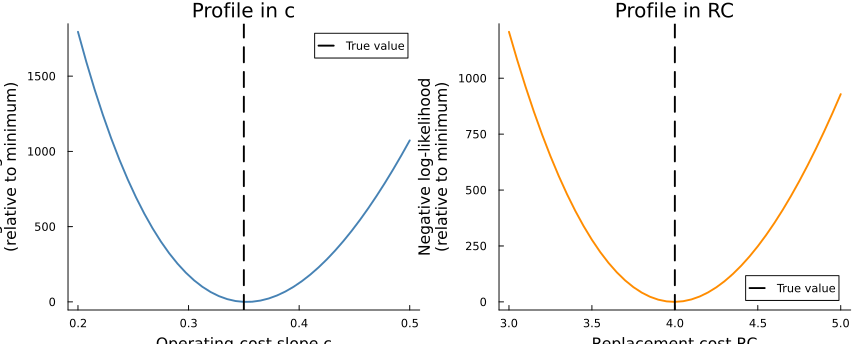

Figure 1: Negative log-likelihood profiles around the true parameters.

```julia
operating_cost_grid = range(0.20, 0.50; length = 41)
replacement_cost_grid = range(3.0, 5.0; length = 41)

operating_cost_profile = [
    -log_likelihood(
        model = model,
        parameters = [operating_cost, true_parameters[2]],
        states = data.states,
        actions = data.actions,
    )
    for operating_cost in operating_cost_grid
]

replacement_cost_profile = [
    -log_likelihood(
        model = model,
        parameters = [true_parameters[1], replacement_cost],
        states = data.states,
        actions = data.actions,
    )
    for replacement_cost in replacement_cost_grid
]

operating_cost_plot = plot(
    operating_cost_grid,
    operating_cost_profile .- minimum(operating_cost_profile);
    color = :steelblue,
    linewidth = 2,
    label = "",
    xlabel = "Operating-cost slope c",
    ylabel = "Negative log-likelihood\n(relative to minimum)",
    title = "Profile in c",
    grid = false,
)
vline!(
    operating_cost_plot,
    [true_parameters[1]];
    color = :black,
    linestyle = :dash,
    linewidth = 2,
    label = "True value",
)

replacement_cost_plot = plot(
    replacement_cost_grid,
    replacement_cost_profile .- minimum(replacement_cost_profile);
    color = :darkorange,
    linewidth = 2,
    label = "",
    xlabel = "Replacement cost RC",
    ylabel = "Negative log-likelihood\n(relative to minimum)",
    title = "Profile in RC",
    grid = false,
)
vline!(
    replacement_cost_plot,
    [true_parameters[2]];
    color = :black,
    linestyle = :dash,
    linewidth = 2,
    label = "True value",
)

profile_minimizer_operating_cost =
    operating_cost_grid[argmin(operating_cost_profile)]
profile_minimizer_replacement_cost =
    replacement_cost_grid[argmin(replacement_cost_profile)]

@show profile_minimizer_operating_cost
@show profile_minimizer_replacement_cost

plot(
    operating_cost_plot,
    replacement_cost_plot;
    layout = (1, 2),
    size = (900, 360),
)
```

#### NFXP Estimates

- The final cell estimates both parameters jointly.

```julia
estimate = estimate_nfxp(
    model = model,
    states = data.states,
    actions = data.actions,
)
estimated_parameters = estimate.parameters

@printf(
    "%-20s %10s %10s\n",
    "Parameter",
    "True",
    "Estimate",
)
@printf(
    "%-20s %10.3f %10.3f\n",
    "Operating cost",
    true_parameters[1],
    estimated_parameters[1],
)
@printf(
    "%-20s %10.3f %10.3f\n",
    "Replacement cost",
    true_parameters[2],
    estimated_parameters[2],
)
@show Optim.converged(estimate.result)
nothing
```

```
Parameter                  True   Estimate
Operating cost            0.350      0.357
Replacement cost          4.000      4.039
Optim.converged(estimate.result) = true
```

### 3.7 Numerical Checks

- These are implementation checks for this synthetic example, not statistical inference.
- The cell checks:

$$\left\lVert
\mathcal{T}_{\widehat{\theta}}\widehat{V}
-\widehat{V}
\right\rVert_{\infty}
<
10^{-8},
\qquad
\left\lVert
\widehat{\theta}-\theta_0
\right\rVert_{\infty}
<
0.25.$$

- It also checks that the outer optimizer reports convergence.

```julia
estimated_solution = solve_model(
    model = model,
    parameters = estimated_parameters,
)
bellman_update = integrated_value(
    choice_values = choice_specific_values(
        model = model,
        parameters = estimated_parameters,
        value = estimated_solution.value,
    ),
)
bellman_residual = maximum(
    abs.(bellman_update .- estimated_solution.value),
)
maximum_parameter_error = maximum(
    abs.(estimated_parameters .- true_parameters),
)

@show estimated_solution.iterations
@show bellman_residual
@show maximum_parameter_error

@assert Optim.converged(estimate.result)
@assert bellman_residual < 1.0e-8
@assert maximum_parameter_error < 0.25
nothing
```

```
estimated_solution.iterations = 445
bellman_residual = 9.135803225035488e-11
maximum_parameter_error = 0.039337351509356466
```

- The Bellman residual checks the inner solution.
- Parameter recovery checks the full simulation-to-estimation path.
- With a finite sample, the estimates need not equal the true parameters exactly.